# Proyecto

Sebastian Jaroszewicz

3/10/2020

```r
knitr::opts_chunk$set(fig.path='Figs/')
```

## Summary

This R Markdown document is the final report of the *Practical Machine Learning* Course of the *John Hopkins Data Science Specialization Specialization* in Data Science. The project was built up in RStudio and published in html format. The pourpouse of this work is to predict the manner in which a group of six people did some exercise described below and use the prediction model to predict 20 different test cases.

## Background

Using devices such as Jawbone Up, Nike FuelBand, and Fitbit it is now possible to collect a large amount of data about personal activity relatively inexpensively. These type of devices are part of the quantified self movement – a group of enthusiasts who take measurements about themselves regularly to improve their health, to find patterns in their behavior, or because they are tech geeks. One thing that people regularly do is quantify how much of a particular activity they do, but they rarely quantify how well they do it. In this project, your goal will be to use data from accelerometers on the belt, forearm, arm, and dumbell of 6 participants. They were asked to perform barbell lifts correctly and incorrectly in 5 different ways. More information is available from the website here:

http://groupware.les.inf.puc-rio.br/har (see the section on the Weight Lifting Exercise Dataset).

## Data

The training data for this project are available here:

https://d396qusza40orc.cloudfront.net/predmachlearn/pml-training.csv

The test data are available here:

https://d396qusza40orc.cloudfront.net/predmachlearn/pml-testing.csv

The data for this project come from this source: http://web.archive.org/web/20161224072740/http:/groupware.les.inf.puc-rio.br/har.

Full reference:

Velloso, E.; Bulling, A.; Gellersen, H.; Ugulino, W.; Fuks, H. **“Qualitative Activity Recognition of Weight Lifting Exercises. Proceedings of 4th International Conference in Cooperation with SIGCHI (Augmented Human ’13)”**. Stuttgart, Germany: ACM SIGCHI, 2013.

## Data Loading and Preprocessing

Load the required libraries for the analysis and set a seed.

```r
library(ggplot2)
library(caret)
library(rpart)
library(rpart.plot)
library(rattle)
library(randomForest)
library(corrplot)
set.seed(5256)
```

```r
url.train <- "http://d396qusza40orc.cloudfront.net/predmachlearn/pml-training.csv"
url.test  <- "http://d396qusza40orc.cloudfront.net/predmachlearn/pml-testing.csv"

# Download data sets
data.train <- read.csv(url(url.train))
data.test <- read.csv(url(url.test))
dim(data.train)
```

```
## [1] 19622   160
```

```r
dim(data.test)
```

```
## [1]  20 160
```

```r
# Create two partitions within training data set.
train.partition <- createDataPartition(data.train$classe, p=0.7, list=FALSE)
set.train <- data.train[train.partition,]
set.test <- data.train[-train.partition,]
dim(set.train)
```

```
## [1] 13737   160
```

```r
dim(set.test)
```

```
## [1] 5885  160
```

There are two sets with 160 variables each. Both sets contains a lot of NAs that must be removed together the near zero variance (NZV) and the ID variables.

```r
# remove NZV
nzv <- nearZeroVar(set.train)
set.train <- set.train[,-nzv]
set.test <- set.test[,-nzv]

# remove NAs
nas <- sapply(set.train, function(x) mean(is.na(x))) > 0.95
set.train <- set.train[,-nas == FALSE]
set.test <- set.test[,-nas == FALSE]

#columns 1 to 5 are identification variables
set.train <- set.train[, -(1:5)]
set.test <- set.test[, -(1:5)]
dim(set.train)
```

```
## [1] 13737    54
```

```r
dim(set.test)
```

```
## [1] 5885   54
```

## Models

In order to predict the outcome variable We will compare two methods and choose the one having the best accuracy. The methods are Decision Tree and Random Forest.

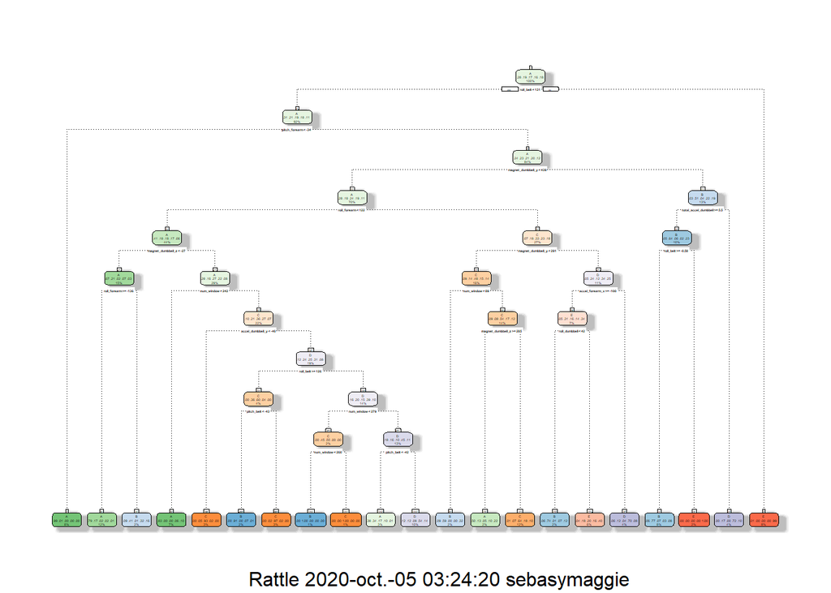

```r
# fit
fit.dt <- rpart(classe ~ ., data = set.train, method="class")
fancyRpartPlot(fit.dt)
```

```r
# prediction
predict.dt <- predict(fit.dt, set.test, type="class")
conf.mat.dt <- confusionMatrix(predict.dt, set.test$classe)
conf.mat.dt
```

```
## Confusion Matrix and Statistics
##
##           Reference
## Prediction    A    B    C    D    E
##          A 1481  192   47   51   67
##          B   68  674   35   76  117
##          C    8   63  821  157   62
##          D   92  143   61  625  135
##          E   25   67   62   55  701
##
## Overall Statistics
##
##                Accuracy : 0.731
##                  95% CI : (0.7195, 0.7423)
##     No Information Rate : 0.2845
##     P-Value [Acc > NIR] : < 2.2e-16
##
##                   Kappa : 0.6589
##
##  Mcnemar's Test P-Value : < 2.2e-16
##
## Statistics by Class:
##
##                      Class: A Class: B Class: C Class: D Class: E
## Sensitivity            0.8847   0.5917   0.8002   0.6483   0.6479
## Specificity            0.9152   0.9376   0.9403   0.9124   0.9565
## Pos Pred Value         0.8058   0.6948   0.7390   0.5919   0.7703
## Neg Pred Value         0.9523   0.9054   0.9571   0.9298   0.9234
## Prevalence             0.2845   0.1935   0.1743   0.1638   0.1839
## Detection Rate         0.2517   0.1145   0.1395   0.1062   0.1191
## Detection Prevalence   0.3123   0.1648   0.1888   0.1794   0.1546
## Balanced Accuracy      0.9000   0.7647   0.8703   0.7804   0.8022
```

```r
# fit
fit.rf <- trainControl(method="cv", number=3, verboseIter=FALSE)
mfit.rf <- train(classe ~ ., data=set.train, method="rf",trControl=fit.rf)
mfit.rf$finalModel
```

```
##
## Call:
##  randomForest(x = x, y = y, mtry = param$mtry)
##                Type of random forest: classification
##                      Number of trees: 500
## No. of variables tried at each split: 27
##
##         OOB estimate of  error rate: 0.27%
## Confusion matrix:
##      A    B    C    D    E  class.error
## A 3904    1    0    0    1 0.0005120328
## B    5 2649    3    1    0 0.0033860045
## C    0    6 2389    1    0 0.0029215359
## D    0    0   12 2239    1 0.0057726465
## E    0    1    0    5 2519 0.0023762376
```

```r
# prediction
predict.rf <- predict(mfit.rf, set.test)
conf.mat.rf <- confusionMatrix(predict.rf, set.test$classe)
conf.mat.rf
```

```
## Confusion Matrix and Statistics
##
##           Reference
## Prediction    A    B    C    D    E
##          A 1674    0    0    0    0
##          B    0 1137    3    0    0
##          C    0    2 1023    4    0
##          D    0    0    0  960    2
##          E    0    0    0    0 1080
##
## Overall Statistics
##
##                Accuracy : 0.9981
##                  95% CI : (0.9967, 0.9991)
##     No Information Rate : 0.2845
##     P-Value [Acc > NIR] : < 2.2e-16
##
##                   Kappa : 0.9976
##
##  Mcnemar's Test P-Value : NA
##
## Statistics by Class:
##
##                      Class: A Class: B Class: C Class: D Class: E
## Sensitivity            1.0000   0.9982   0.9971   0.9959   0.9982
## Specificity            1.0000   0.9994   0.9988   0.9996   1.0000
## Pos Pred Value         1.0000   0.9974   0.9942   0.9979   1.0000
## Neg Pred Value         1.0000   0.9996   0.9994   0.9992   0.9996
## Prevalence             0.2845   0.1935   0.1743   0.1638   0.1839
## Detection Rate         0.2845   0.1932   0.1738   0.1631   0.1835
## Detection Prevalence   0.2845   0.1937   0.1749   0.1635   0.1835
## Balanced Accuracy      1.0000   0.9988   0.9979   0.9977   0.9991
```

Therefore the Random Forest method is selected

```r
prediction <- predict(mfit.rf, data.test)
prediction
```

```
##  [1] B A B A A E D B A A B C B A E E A B B B
## Levels: A B C D E
```